# Prediction Assignment Writeup for Coursera Practical Machine Learning class

Christoffer Vig

Wednesday, February 18, 2015

This document was created for the prediction assignment writeup as part of Coursera Practical Machine Learning class (Johns Hopkins University). I want to show how I built a machine learning algorithm to predict activity quality from activity monitors. More information on the dataset and the problem can be found at (http://groupware.les.inf.puc-rio.br/har)[http://groupware.les.inf.puc-rio.br/har]

```r
library(caret)
datacsv <- read.csv('pml-training.csv')
```

The “classe” variable contains the information we want to predict. It contains 5 unique values.

```r
table(datacsv$classe)
```

```
##
##    A    B    C    D    E
## 5580 3797 3422 3216 3607
```

The column new_window contains information on the time window for prediction. Rows with column “new_window=yes”" contains statistical calculations on the other columns, so I remove this from the dataset.

```r
fulltraindata <- datacsv[datacsv$new_window == 'no', ]
```

The dataset contains a lot of empty and missing data, I remove this as it will not contribute to building a model.

```r
pmltraining <- fulltraindata[!sapply(fulltraindata, function(x) all(x == ""|| is.na(x)))]
```

```r
pmltraining[1:7] <- list(NULL)
names(pmltraining)
```

```
##  [1] "roll_belt"            "pitch_belt"           "yaw_belt"
##  [4] "total_accel_belt"     "gyros_belt_x"         "gyros_belt_y"
##  [7] "gyros_belt_z"         "accel_belt_x"         "accel_belt_y"
## [10] "accel_belt_z"         "magnet_belt_x"        "magnet_belt_y"
## [13] "magnet_belt_z"        "roll_arm"             "pitch_arm"
## [16] "yaw_arm"              "total_accel_arm"      "gyros_arm_x"
## [19] "gyros_arm_y"          "gyros_arm_z"          "accel_arm_x"
## [22] "accel_arm_y"          "accel_arm_z"          "magnet_arm_x"
## [25] "magnet_arm_y"         "magnet_arm_z"         "roll_dumbbell"
## [28] "pitch_dumbbell"       "yaw_dumbbell"         "total_accel_dumbbell"
## [31] "gyros_dumbbell_x"     "gyros_dumbbell_y"     "gyros_dumbbell_z"
## [34] "accel_dumbbell_x"     "accel_dumbbell_y"     "accel_dumbbell_z"
## [37] "magnet_dumbbell_x"    "magnet_dumbbell_y"    "magnet_dumbbell_z"
## [40] "roll_forearm"         "pitch_forearm"        "yaw_forearm"
## [43] "total_accel_forearm"  "gyros_forearm_x"      "gyros_forearm_y"
## [46] "gyros_forearm_z"      "accel_forearm_x"      "accel_forearm_y"
## [49] "accel_forearm_z"      "magnet_forearm_x"     "magnet_forearm_y"
## [52] "magnet_forearm_z"     "classe"
```

## Algoritm selection

I am now left with 52 variables. Random forest is an algorithm that is especially well suited to deal with noisy data without need for extensive preprocessing. It grows decision trees using random sample with replacement (bootstrapping) and random feature selection. It has built in corrections for overfitting, the estimated class is the mean predicion of all generated trees.

### Cross validation/OOB error rate

Using random forest, about one third of the data set is left out for testing on each tree generation. After each tree generation, each of the test data cases is run down the constructed tree to get a test set classification. After the complete run is finished, the class for each case with the most votes j is compared to the true class n. The out of bonds error estimate is the proportion of times that j is not equal to the true class of n averaged over all cases. This means it is really not necessary to perform cross validation as part of preprocessing, the OOB error rate is returned directly from the model. But for this excercise I will split the data into train and test, in order to deliver a proper test for prediction.

## Split dataset into test and train

I split the training dataset into a training and testing set, using 60% of the data for training

```r
intrain <- createDataPartition(pmltraining$classe,p=0.6, list=FALSE)
testClas = pmltraining[-intrain,]
trainClas = pmltraining[intrain,]
```

## Random forest on training set

I now want to calculate the random Forest model on the training data

```r
library(randomForest)
modltrain <- randomForest(classe ~. , data = trainClas)
modltrain
```

```
##
## Call:
##  randomForest(formula = classe ~ ., data = trainClas)
##                Type of random forest: classification
##                      Number of trees: 500
## No. of variables tried at each split: 7
##
##         OOB estimate of  error rate: 0.67%
## Confusion matrix:
##      A    B    C    D    E class.error
## A 3279    3    0    0    1 0.001218398
## B   15 2209    7    0    0 0.009861049
## C    0   14 1995    3    0 0.008449304
## D    0    0   24 1863    2 0.013763896
## E    0    0    1    7 2109 0.003778932
```

```r
pred = predict(modltrain,newdata=testClas)
confusionMatrix(data = pred,reference = testClas$classe)
```

```
## Confusion Matrix and Statistics
##
##           Reference
## Prediction    A    B    C    D    E
##          A 2186    9    0    0    0
##          B    2 1475    5    0    0
##          C    0    3 1335   12    1
##          D    0    0    0 1245    6
##          E    0    0    0    1 1404
##
## Overall Statistics
##
##                Accuracy : 0.9949
##                  95% CI : (0.9931, 0.9964)
##     No Information Rate : 0.2847
##     P-Value [Acc > NIR] : < 2.2e-16
##
##                   Kappa : 0.9936
##  Mcnemar's Test P-Value : NA
##
## Statistics by Class:
##
##                      Class: A Class: B Class: C Class: D Class: E
## Sensitivity            0.9991   0.9919   0.9963   0.9897   0.9950
## Specificity            0.9984   0.9989   0.9975   0.9991   0.9998
## Pos Pred Value         0.9959   0.9953   0.9882   0.9952   0.9993
## Neg Pred Value         0.9996   0.9981   0.9992   0.9980   0.9989
## Prevalence             0.2847   0.1935   0.1744   0.1637   0.1836
## Detection Rate         0.2845   0.1920   0.1737   0.1620   0.1827
## Detection Prevalence   0.2857   0.1929   0.1758   0.1628   0.1828
## Balanced Accuracy      0.9987   0.9954   0.9969   0.9944   0.9974
```

This reports an accuracy of 0.99, which is extremely good measure. A simple check on the variable importance will reveal something about what variables were most important in creating the model.

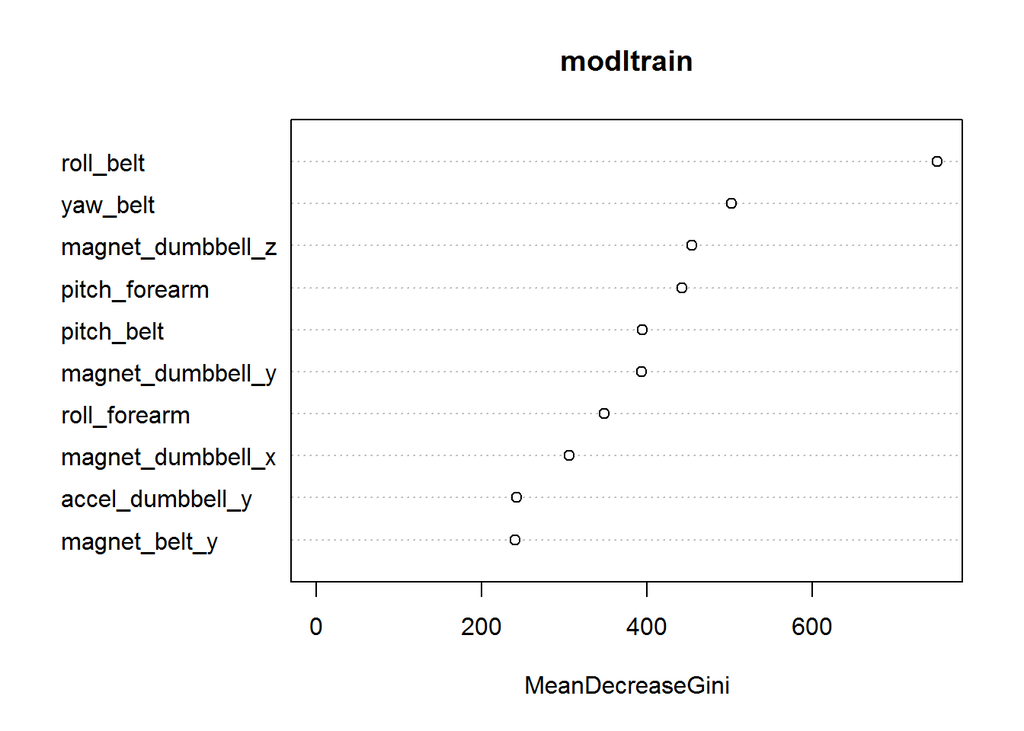

```r
varImpPlot(modltrain, n.var=10)
```

This shows that the roll_belt feature was most important in deciding the class, followed by yaw_belt.